# Une analyse des trajets en taxis à New York avec R

10 janvier 2022

### Pierre Corbin / Charlie Deshayes / Elyott Tigier

##### Master 2 SIGAT

```r
setwd("C:/Users/21701140/Desktop/ScriptR_Pierre_Elyott_Charlie/ScriptR_Pierre_Elyott_Charlie")
```

- Changer le répertoire de travail

## Chargement des librairies

```r
library(tidyverse)
library(lubridate)
library(sf)
library(cluster)
```

```r
library(cartography)
library(scales)
library(treemap)
```

## Import des données

```r
taxis <- read.csv("yellow_tripdata_2021-07.csv")
```

## Import des données géographiques

```r
taxis_zones <- st_read(dsn = "C:/Users/21701140/Desktop/ScriptR_Pierre_Elyott_Charlie/ScriptR_Pierre_Elyott_Charlie/taxi_zones/taxi_zones.shp", stringsAsFactors = FALSE)
```

Penser à redéfinir le chemin d’accès

## Visualisation des données géographiques catégorisé par quartier

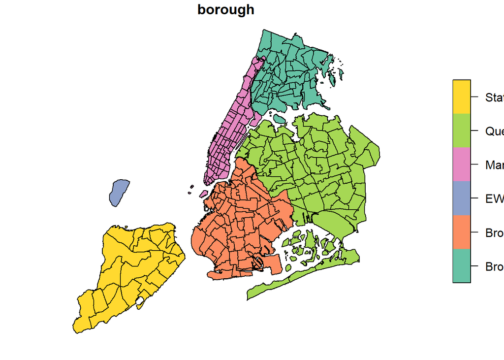

```r
plot(taxis_zones["borough"])
```

# Préparation des données :

## Renommer les colonnes

```r
taxis <- taxis %>% select(
  fournisseur = VendorID,
  depart = tpep_pickup_datetime,
  arrivee = tpep_dropoff_datetime,
  nb_passagers = passenger_count,
  distance = trip_distance,
  tarif = RatecodeID,
  zone_depart = PULocationID,
  zone_arrivee = DOLocationID,
  paiement = payment_type,
  montant_compteur = fare_amount,
  pourboire = tip_amount,
  montant_total = total_amount,
  type_envoi = store_and_fwd_flag)
```

# Reclassement de la colonne du type de paiement

```r
taxis <- taxis %>% mutate(paiement = case_when((paiement == 1) ~ "Carte",
                                            (paiement == 2) ~ "Espèce",
                                            (paiement == 3) ~ "Gratuit",
                                            (paiement == 4) ~ "Litige",
                                            (paiement == 5) ~ "Inconnu",
                                            (paiement == 6) ~ "Annulation"))
```

# Transformation de l’unité de la distance parcourue de miles à kilomètres

```r
taxis <- taxis %>% mutate(dist_km = distance*1.60934)
```

```r
taxis <- taxis %>% select(-distance)
```

# Sélection et renommage des variables du fichier de forme

```r
taxis_zones <- taxis_zones %>% select(
  ID_zone = LocationID,
  zone,
  quartier = borough,
  surface = Shape_Area,
  geometrie = geometry, )
```

On ne garde pas *“OBJECTID”*, *“Shape_leng”*

# Suppression des dates de départ non comprise dans le mois de juillet

```r
taxis <- taxis %>% filter(grepl('2021-07',depart))
```

# Suppression des lignes avec des des valeurs manquantes

```r
taxis[taxis==""] <- NA
```

#Pour supprimer les valeurs manquantes:

```r
taxis <- taxis %>% na.omit()
```

On a environ **130 000** lignes qui possèdent au moins un “Not Available”

# Suppression des valeurs aberrantes

```r
summary(taxis)
```

```
##   fournisseur       depart            arrivee           nb_passagers
##  Min.   :1.000   Length:2690729     Length:2690729     Min.   :0.000
##  1st Qu.:1.000   Class :character   Class :character   1st Qu.:1.000
##  Median :2.000   Mode  :character   Mode  :character   Median :1.000
##  Mean   :1.699                                         Mean   :1.461
##  3rd Qu.:2.000                                         3rd Qu.:2.000
##  Max.   :2.000                                         Max.   :9.000
##      tarif         zone_depart     zone_arrivee     paiement
##  Min.   : 1.000   Min.   :  1.0   Min.   :  1.0   Length:2690729
##  1st Qu.: 1.000   1st Qu.:132.0   1st Qu.:107.0   Class :character
##  Median : 1.000   Median :162.0   Median :162.0   Mode  :character
##  Mean   : 1.066   Mean   :163.7   Mean   :161.7
##  3rd Qu.: 1.000   3rd Qu.:233.0   3rd Qu.:234.0
##  Max.   :99.000   Max.   :265.0   Max.   :265.0
##  montant_compteur    pourboire       montant_total      type_envoi
##  Min.   :-550.00   Min.   :-91.660   Min.   :-554.05   Length:2690729
##  1st Qu.:   6.50   1st Qu.:  0.000   1st Qu.:  11.63   Class :character
##  Median :   9.50   Median :  2.000   Median :  14.76   Mode  :character
##  Mean   :  13.06   Mean   :  2.349   Mean   :  19.27
##  3rd Qu.:  14.50   3rd Qu.:  3.000   3rd Qu.:  20.47
##  Max.   :1320.00   Max.   :400.000   Max.   :1320.80
##     dist_km
##  Min.   :   0.000
##  1st Qu.:   1.770
##  Median :   2.929
##  Mean   :   5.144
##  3rd Qu.:   5.295
##  Max.   :1409.299
```

```r
quantile(taxis$dist_km, 0.999)
```

```
##   99.9%
## 48.9605
```

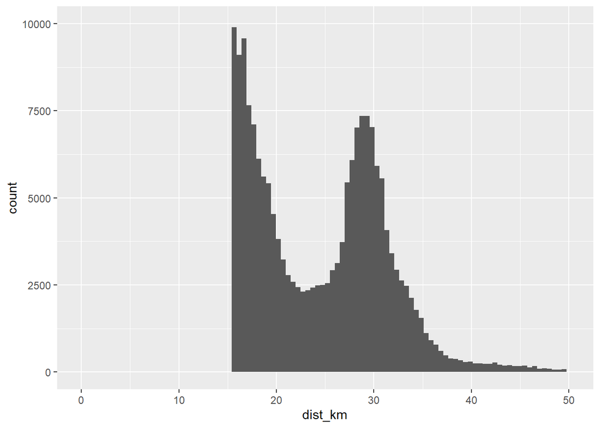

```r
ggplot(taxis, aes(x=dist_km)) + geom_histogram(bins = 100) + xlim(0,50) + ylim(0,10000)
```

```r
taxis <- taxis %>% filter(dist_km < 50, montant_total >= 0)
```

# Enrichissement du jeu de données à plat

## Ajout de l’information sur le jour de la semaine, le jour du mois et l’heure dans le jeu de données avec la fonction wday, day et hour

```r
taxis <- taxis %>% mutate(jour_semaine = wday(depart, label = TRUE, abbr = FALSE), jour_mois = day(depart), heure = hour(depart))
```

## Ajout de l’information sur la période de la semaine (semaine ou le week-end)

```r
taxis$sem_we <- ifelse(taxis$jour_semaine == "samedi" | taxis$jour_semaine == "dimanche", "Week-end", "Semaine")
```

## Ajout de l’information sur la période la journée

```r
taxis <- taxis %>% mutate(periode_jour = case_when((heure < 6) ~ "Nuit",
                                                (heure >= 6) & (12 > heure) ~ "Matin",
                                                (heure >= 12) & (18 > heure) ~ "Après-midi",
                                                (heure >= 18) ~ "Soir"))
```

## Ajout de la durée du trajet

```r
taxis$depart <- as_datetime(taxis$depart)
```

```r
taxis$arrivee <- as_datetime(taxis$arrivee)
```

```r
taxis$duree <- taxis$arrivee-taxis$depart
```

## Suppression des valeurs de durée aberrantes

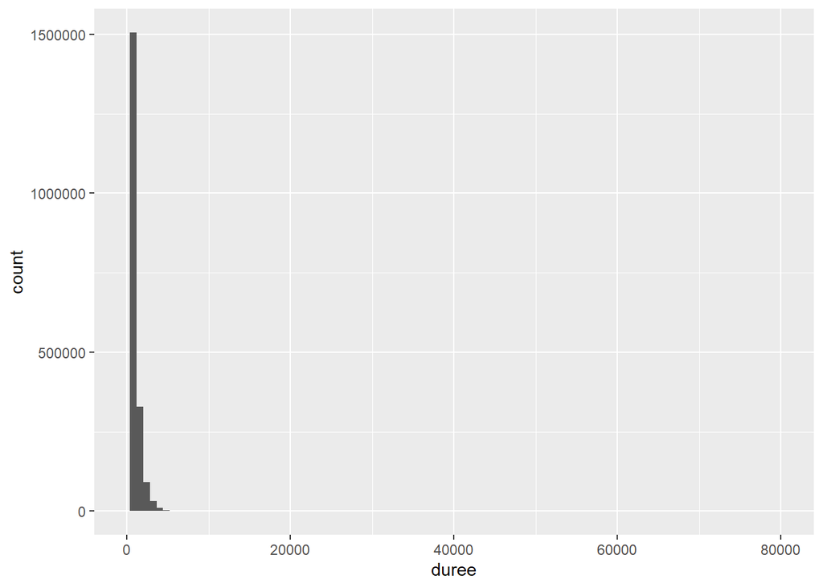

```r
ggplot(taxis, aes(x=duree)) + geom_histogram(bins = 100) + xlim(0,80000)
```

```r
quantile(taxis$duree, 0.99)
```

```
## Time difference of 3371 secs
```

```r
taxis <- taxis %>% filter(duree >= 0, duree < 30000)
```

# Graphiques

## Part des types de paiement utilisés

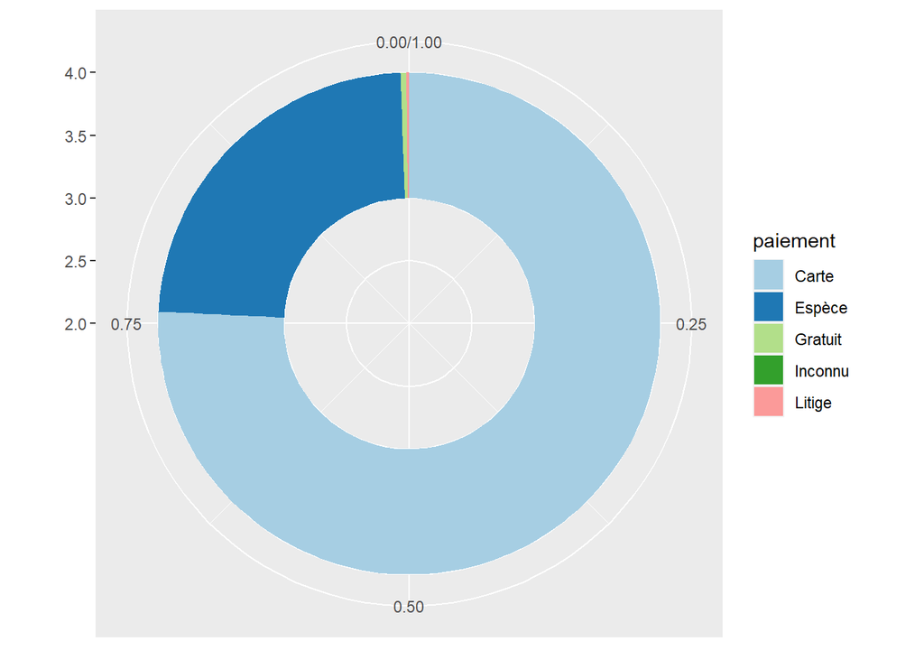

```r
type_paiement <- taxis %>% group_by(paiement) %>% summarise(nb = n())
type_paiement$fraction = type_paiement$nb /sum(type_paiement$nb)
type_paiement$ymax = cumsum(type_paiement$fraction)
type_paiement$ymin = c(0, head(type_paiement$ymax, n=-1))

ggplot(type_paiement, aes(ymax=ymax, ymin=ymin, xmax=4, xmin=3, fill=paiement)) +
  geom_rect() + scale_fill_brewer(palette = "Paired") + coord_polar(theta="y") + xlim(c(2, 4))
```

## Nombre de trajets au cours de la journée

```r
diff_semaine_weekend <- taxis %>% group_by(periode_jour, sem_we) %>% summarise(nb_trajet = n())
```

### Changement de l’ordre des périodes de la journée

```r
diff_semaine_weekend$periode_jour <- factor(diff_semaine_weekend$periode_jour, levels = c("Matin", "Après-midi", "Soir", "Nuit"))
```

### Création du graphique

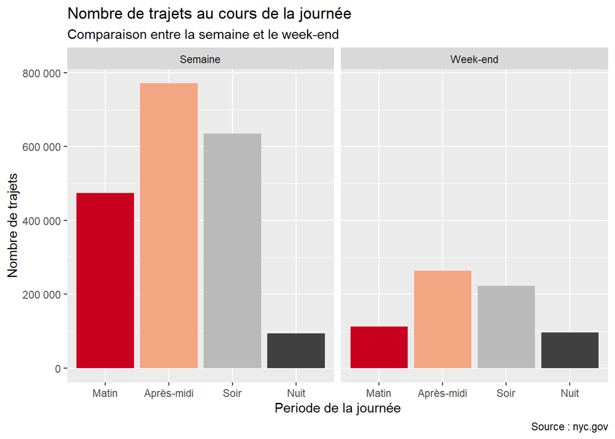

```r
ggplot(diff_semaine_weekend) + geom_col(aes(x=periode_jour, y=nb_trajet, fill=periode_jour), show.legend = FALSE) +
scale_fill_brewer(palette="RdGy") +
scale_y_continuous(labels=function(x) format(x, big.mark = " ", scientific = FALSE)) +
labs(x = "Periode de la journée", y = "Nombre de trajets", title ="Nombre de trajets au cours de la journée", subtitle = "Comparaison entre la semaine et le week-end", caption = "Source : nyc.gov") +
facet_wrap(~sem_we)
```

## Nombre de trajets par journée

```r
nb_jour <- taxis %>% group_by(jour_semaine) %>% summarise(nb_trajet = n())
```

### Changement de l’ordre des journée

```r
nb_jour$jour_semaine <- factor(nb_jour$jour_semaine, levels = c("lundi", "mardi", "mercredi", "jeudi", "vendredi", "samedi", "dimanche"))
```

### Création du graphique

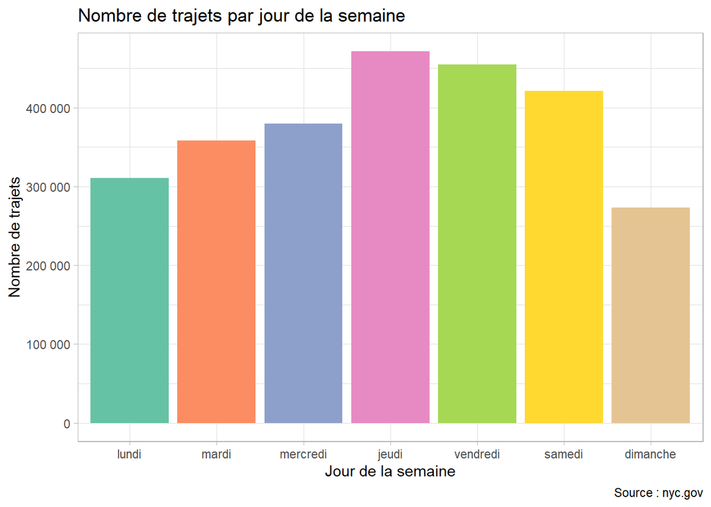

```r
ggplot(nb_jour) +
  geom_col(aes(x=jour_semaine, y=nb_trajet, fill=jour_semaine), show.legend=FALSE) +
  theme_light() +
  scale_fill_brewer(palette="Set2") +
  scale_y_continuous(labels=function(x) format(x, big.mark = " ", scientific = FALSE)) +
  labs(x = "Jour de la semaine", y = "Nombre de trajets") +
  labs(title ="Nombre de trajets par jour de la semaine") +
  labs(caption = "Source : nyc.gov")
```

## Nombre de trajets par journée sur le mois

```r
nb_jour_mois <- taxis %>% group_by(jour_mois, jour_semaine) %>% summarise(nb_trajet = n())
```

### Changement de l’ordre des journée

```r
nb_jour_mois$jour_semaine <- factor(nb_jour_mois$jour_semaine, levels = c("lundi", "mardi", "mercredi", "jeudi", "vendredi", "samedi", "dimanche"))
```

### Création du graphique

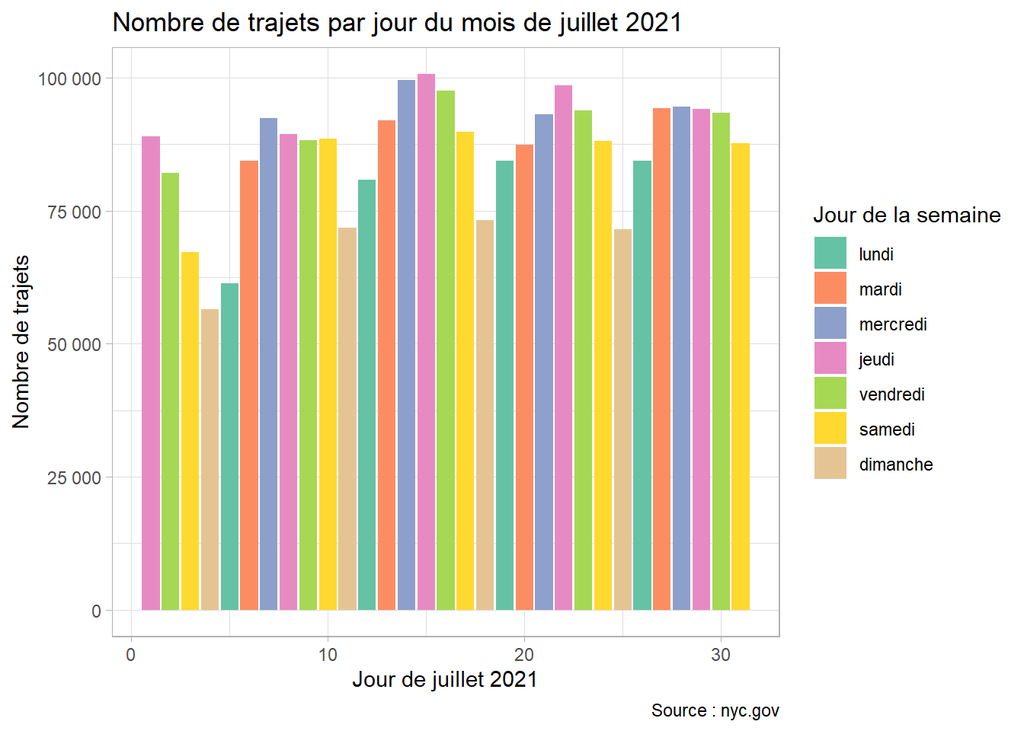

```r
ggplot(nb_jour_mois) +
  geom_col(aes(x=jour_mois, y=nb_trajet, fill=jour_semaine)) +
  theme_light() +
  scale_fill_brewer(palette="Set2") +
  scale_y_continuous(labels=function(x) format(x, big.mark = " ", scientific = FALSE)) +
  labs(x = "Jour de juillet 2021", y = "Nombre de trajets") +
  labs(title ="Nombre de trajets par jour du mois de juillet 2021") +
  labs(caption = "Source : nyc.gov") +
  labs(fill="Jour de la semaine")
```

## Evolution du nombre de trajets par jour et par heure

### Tableau récapitulatif

```r
HeureJournee<- taxis %>% group_by(jour_semaine, Heure=heure) %>% summarise(NbTrajet=n())
```

### Changement de l’ordre des journées

```r
HeureJournee$jour_semaine <- factor(HeureJournee$jour_semaine ,levels = c("lundi", "mardi", "mercredi", "jeudi", "vendredi", "samedi", "dimanche"))
```

### Création du graphique

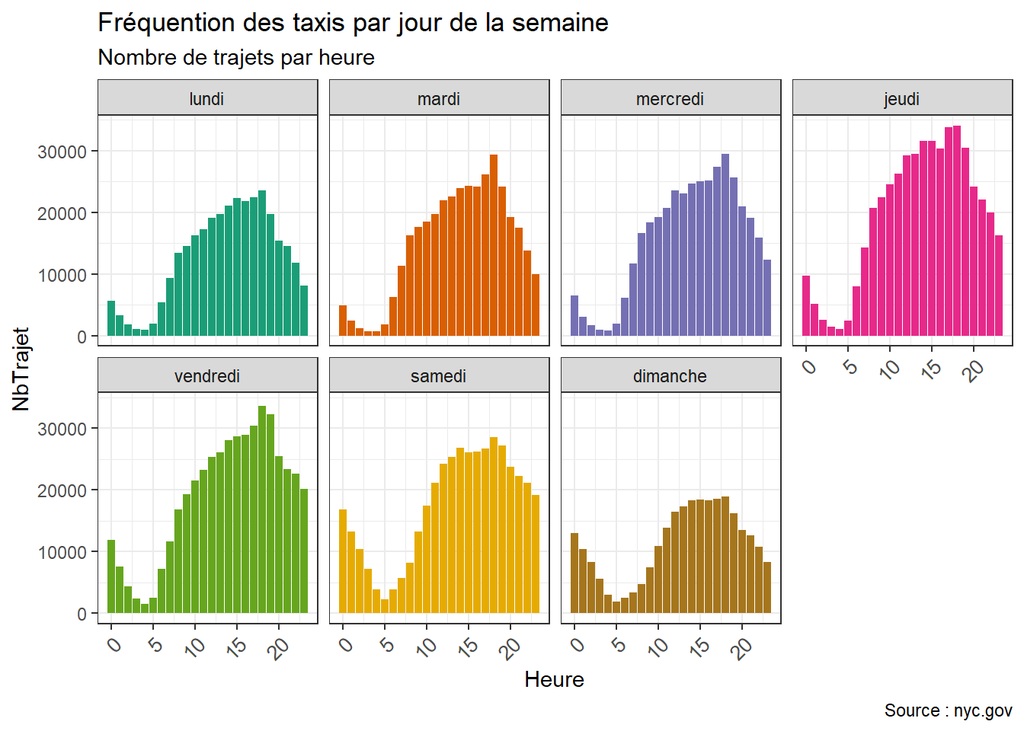

```r
ggplot(HeureJournee) + geom_col(aes(x = Heure, y = NbTrajet, fill=jour_semaine)) +
  scale_fill_brewer(palette="Dark2") +
  theme_bw() +
  facet_wrap(~jour_semaine, nrow =2 ) +
  theme(legend.position = "none") +
  labs(title = "Fréquention des taxis par jour de la semaine", subtitle = "Nombre de trajets par heure") + labs(caption = "Source : nyc.gov") +
  theme(axis.text.x = element_text(angle = 45, hjust = 1, size = 10))
```

## Nombre de trajets en fonction de la durée

```r
taxis <- taxis %>% mutate(duree_quali = case_when(duree < 300 ~ "Moins de 5 min",
                                                  duree > 300 & duree < 600 ~ "Entre 5 et 10 min",
                                                  duree > 600 & duree < 900 ~ "Entre 10 et 15 min",
                                                  duree > 900 & duree < 1800 ~ "Entre 15 et 30 min",
                                                  duree > 1800 & duree < 3600 ~ "Entre 30 min et 1 heure",
                                                  duree > 3600 ~ "Plus d 1 heure"))

nb_duree <- taxis %>% group_by(duree_quali) %>% summarise(nb_trajet = n())
```

### Création de la treemap

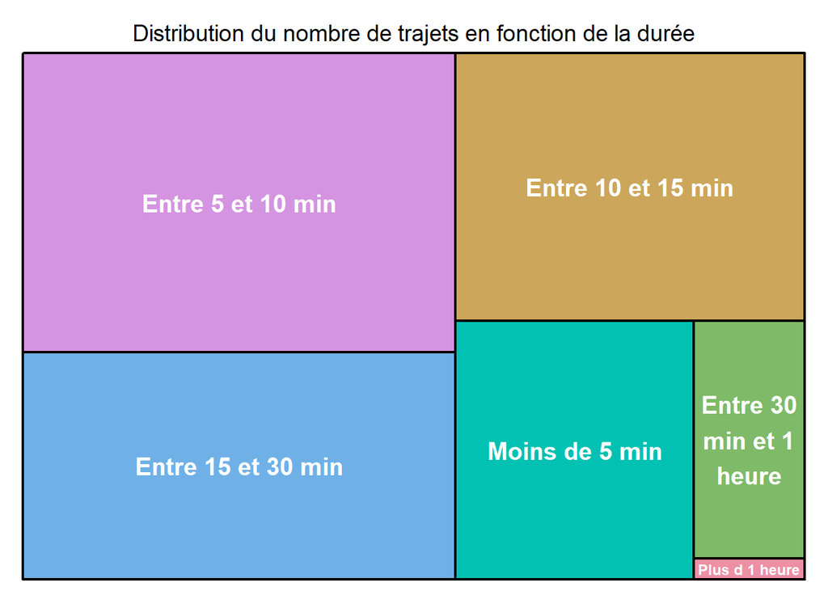

```r
treemap(nb_duree, index=c("duree_quali"),vSize="nb_trajet", type="index",
    title = "Distribution du nombre de trajets en fonction de la durée",
    fontsize.labels=c(15,12),
    fontcolor.labels=c("white","orange"),
    fontface.labels=c(2,1),
    bg.labels=c("transparent"),
    align.labels=list(
        c("center", "center"),
        c("right", "bottom")),
    overlap.labels=0.5)
```

# Départs en taxis

## Création du tableau récapitulatif

```r
nb_depart_zone <- taxis %>% group_by(zone_depart) %>% summarise(nb_trajet = n())
```

## Jointure attributaire

```r
zone_nb_depart <- merge(taxis_zones,nb_depart_zone, by.x= "ID_zone", by.y="zone_depart")
```

## Création de la carte

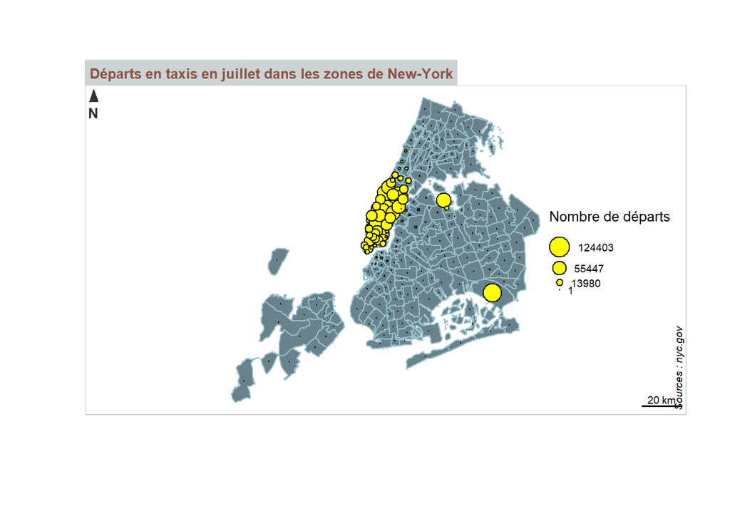

```r
plot(st_geometry(zone_nb_depart),
    col = "lightblue4",
    border = "lightblue3",
    bg = "white")

propSymbolsLayer(
    x = zone_nb_depart,
    var = "nb_trajet",
    inches = 0.1,
    symbols = "circle", col =  "yellow",
    legend.pos = "right", border = "black",
    legend.title.txt = "Nombre de départs",
    legend.style = "e")
layoutLayer(title = "Départs en taxis en juillet dans les zones de New-York",
            author = "Sources : nyc.gov",
            scale = 20, frame = TRUE, col = "#cdd2d4", coltitle = "#8A5543",
            north(pos = "topleft"), tabtitle=TRUE, horiz = FALSE)
```

# Pourboire par zones

## Création du tableau récapitulatif

```r
pourboire <- taxis %>% group_by(zone_depart) %>% summarise (pourboire_moy=mean(pourboire))
```

## Jointure attributaire

```r
pourboireok <- merge(taxis_zones,pourboire, by.x = "ID_zone", by.y ="zone_depart")
```

## Création de la carte

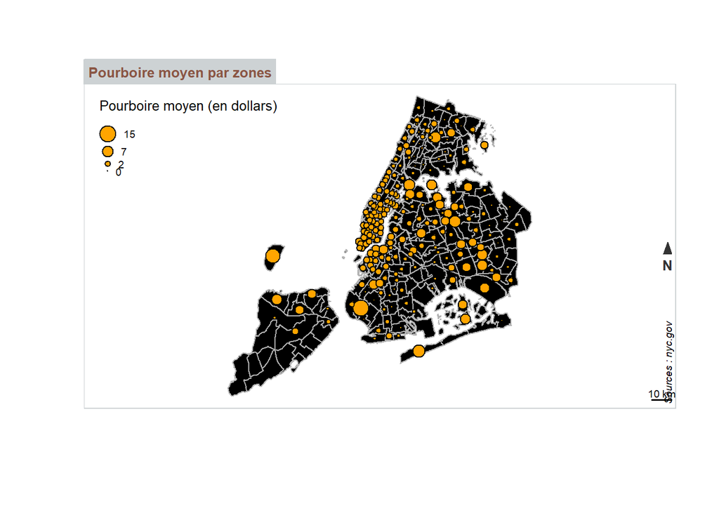

```r
plot(st_geometry(taxis_zones),
    col = "black",
    border = "grey70",
    bg = "white")
propSymbolsLayer(
    x = pourboireok,
    var = "pourboire_moy",
    inches = 0.08,
    symbols = "circle", col =  "orange",
    legend.pos = "topleft", border = "black",
    legend.title.txt = "Pourboire moyen (en dollars)",
    legend.style = "e")
layoutLayer(title = "Pourboire moyen par zones",
         author = "Sources : nyc.gov",
         scale = 10, frame = TRUE, col = "#cdd2d4", coltitle = "#8A5543",
         north(pos = "right"), tabtitle=TRUE, horiz = FALSE)
```

# Carte montrant le coûts du kilomètre par zone

## Création du tableau récapitulatif

```r
Prixkm <- taxis %>% group_by (zone_arrivee) %>% summarise (MontantMoy = mean(montant_compteur), DistMoy = mean(dist_km))
```

## Calcul du coûts

```r
Prixkm <- Prixkm %>% mutate (Coutskm = MontantMoy/DistMoy)
```

## Jointure attributaire

```r
Prixkmok <- merge (taxis_zones, Prixkm, by.x = "ID_zone", by.y = "zone_arrivee")
```

## Création de la carte

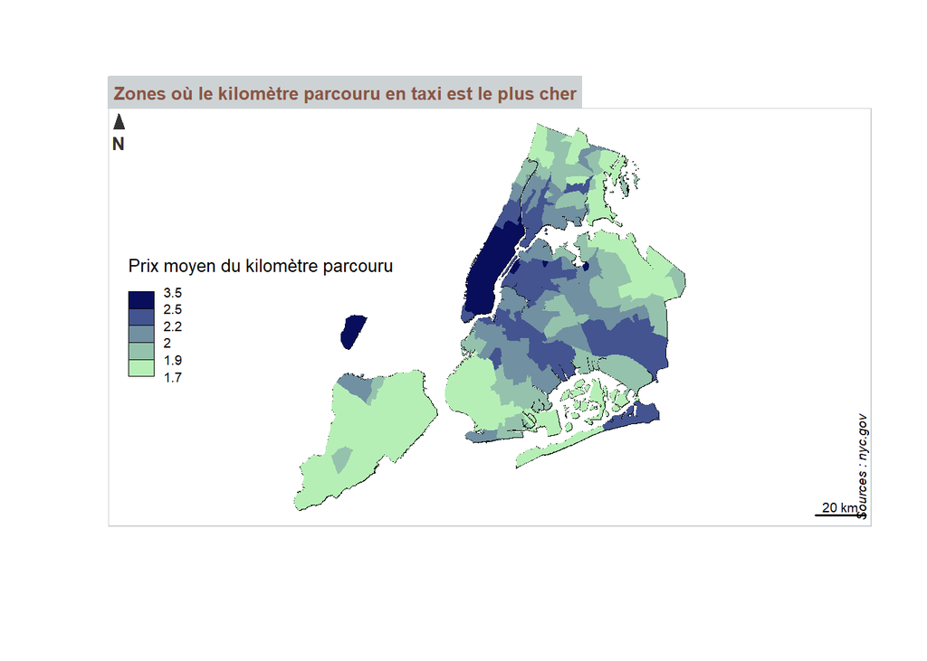

```r
plot(st_geometry(Prixkmok), col = "grey90", border = "black", lwd = 0.1)

choroLayer(x = Prixkmok, var = "Coutskm", border = NA,
           col = carto.pal("turquoise.pal", 5), legend.pos = "left",
           add = TRUE, method = "quantile", nclass = 5,
           legend.values.rnd = 1,legend.title.txt = "Prix moyen du kilomètre parcouru")

layoutLayer(title = "Zones où le kilomètre parcouru en taxi est le plus cher",
            author = "Sources : nyc.gov",
            scale = 20, frame = TRUE, col = "#cdd2d4", coltitle = "#8A5543",
            north(pos = "topleft"), tabtitle=TRUE, horiz = FALSE)
```

Il semble important de préciser que le montant compteur des taxis est fonction du temps passé et non pas de la distance parcouru. Cependant, le ratio montant/distance permet de mettre en évidence les zones où le temps passé en taxi est conséquent et donc les zones de congestion.

# Classification ascendante hiérarchique

## On duplique le jeu de données “taxis_zones” pour avoir un jeu de données “départ” et un jeu de données “arrivée” pour effectuer les CAH

```r
taxis_zones_depart <- taxis_zones %>% select(ID_zone_dep = ID_zone, zone_dep = zone, quartier_dep = quartier, surface_dep = surface, geometrie_dep = geometrie)
```

```r
taxis_zones_arrivee <- taxis_zones %>% select(ID_zone_arr = ID_zone, zone_arr = zone, quartier_arr = quartier, surface_arr = surface, geometrie_arr = geometrie)
```

## Zones de départ

```r
taxis_cah_depart <- taxis %>% group_by(zone_depart) %>% summarise(
            nb_trajets = n(),
            passagers_moyen = mean(nb_passagers),
            distance_moyenne = mean(dist_km),
            montant_moyen = mean(montant_total))
```

```r
taxis_cah_OK_depart <- data.frame(taxis_cah_depart[, c("nb_trajets", "passagers_moyen", "distance_moyenne", "montant_moyen")])
```

### Centrage et réduction des données

```r
taxis_cah_scale_depart <- scale(taxis_cah_OK_depart)
```

```r
taxis_cah_fait_depart <- agnes(taxis_cah_scale_depart,
                metric = "euclidean",
                method = "ward")
```

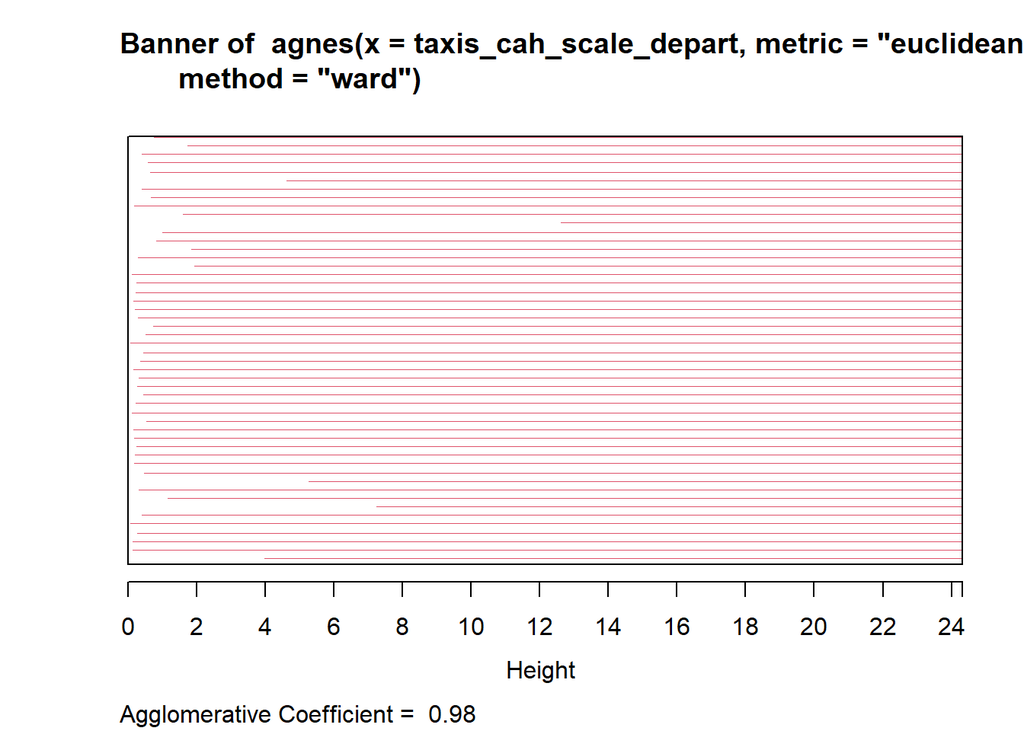

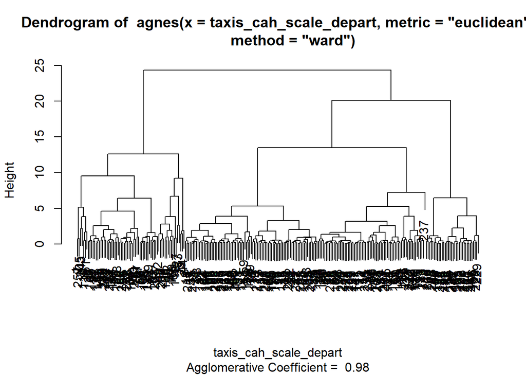

```r
plot(taxis_cah_fait_depart)
```

### Affichage du graphique des gains d’inertie inter-classe

```r
sortedHeight_depart<- sort(taxis_cah_fait_depart$height, decreasing= TRUE)
```

```r
relHeight_depart<-sortedHeight_depart/ sum(sortedHeight_depart)*100
```

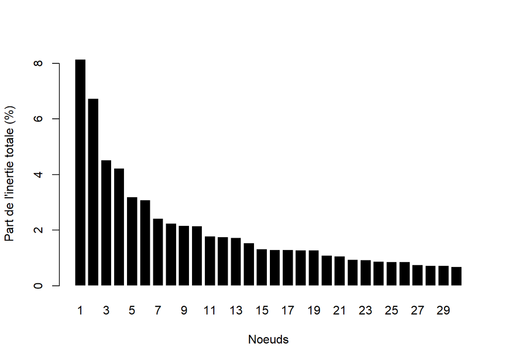

```r
barplot(relHeight_depart[1:30],names.arg=seq(1, 30, 1), col= "black", border= "white", xlab= "Noeuds",ylab= "Part de l'inertie totale (%)")
```

```r
clus_zones_depart <- cutree(taxis_cah_fait_depart, k = 4)
```

```r
zones_cluster_depart <- as.data.frame(taxis_cah_depart)
```

```r
zones_cluster_depart$clus <- factor(clus_zones_depart,
                    levels = 1:4,
                    labels = paste("Classe", 1:4))
```

```r
zones_cluster_depart <- zones_cluster_depart %>% select (ID_zone_dep = zone_depart, nb_trajets, passagers_moyen, distance_moyenne, montant_moyen, clus)
```

### Création d’un tableau récapitulatif des classes

```r
recap_clus_zones_depart <- zones_cluster_depart %>% group_by(clus) %>%
                                    summarise(nb_trajets_moy = mean(nb_trajets),
                                                passagers_moyen = mean(passagers_moyen),
                                                distance_moyenne = mean(distance_moyenne),
                                                montant_moyen = mean(montant_moyen))
```

```r
synthese_cah_taxis_depart <- recap_clus_zones_depart %>% mutate(
  NB_TRAJETS_MOY = mean(taxis_cah_OK_depart$nb_trajets),
  PASSAGERSMOY = mean(taxis_cah_OK_depart$passagers_moyen),
  DISTANCEMOY = mean(taxis_cah_OK_depart$distance_moyenne),
  MONTANTMOY = mean(taxis_cah_OK_depart$montant_moyen),
  nb_trajets = (nb_trajets_moy - NB_TRAJETS_MOY)/NB_TRAJETS_MOY*100,
  passagers = (passagers_moyen - PASSAGERSMOY)/PASSAGERSMOY*100,
  distance = (distance_moyenne - DISTANCEMOY)/DISTANCEMOY*100,
  montant = (montant_moyen - MONTANTMOY)/MONTANTMOY*100)
```

```r
synthese_cah_taxis_OK_depart <- data.frame(synthese_cah_taxis_depart[, c("clus", "nb_trajets", "passagers", "distance", "montant")])
```

```r
gather_depart <- synthese_cah_taxis_OK_depart %>% gather(key=variable, value= "value", nb_trajets:montant)
```

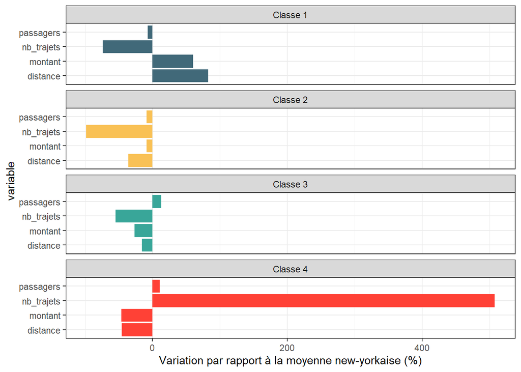

```r
ggplot(gather_depart, aes(x=variable, y=value, fill=clus)) +
  geom_bar(stat = "identity") +
  coord_flip() +
  scale_fill_manual(values=c("#416979","#f9c155","#39a699","#FF4136","#FF851B", "#1f78b4")) +
  ylab("Variation par rapport à la moyenne new-yorkaise (%)") +
  theme_bw() +
  theme(legend.position = "none") +
  facet_wrap(~clus, ncol = 1)
```

### Jointure du résultat de la typologie dans la couche des zones de départ

```r
zones_trajets_cah_depart <- merge(taxis_zones_depart, zones_cluster_depart, by = "ID_zone_dep")
```

### Création de la carte

```r
par(mar=c(0,0,1.2,0))
```

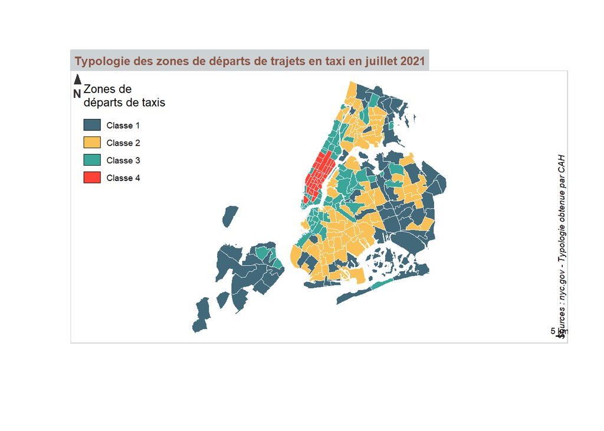

```r
typoLayer(
  x = zones_trajets_cah_depart,
  var="clus",
  col = c("#416979","#f9c155","#39a699","#FF4136","#FF851B", "#1f78b4"),
  lwd = 0.1,
  border = "white",
  legend.values.order = c("Classe 1",
                        "Classe 2",
                        "Classe 3",
                        "Classe 4"),
  legend.pos = "topleft",
  legend.title.txt = "Zones de \ndéparts de taxis",
  legend.nodata = "Aucun départ")

layoutLayer(title = "Typologie des zones de départs de trajets en taxi en juillet 2021",
            author = "Sources : nyc.gov - Typologie obtenue par CAH",
            scale = 5, frame = TRUE, col = "#cdd2d4", coltitle = "#8A5543",
            north(pos = "topleft"), tabtitle=TRUE, horiz = FALSE)
```

## Zones d’arrivée

```r
taxis_cah_arrivee <- taxis %>% group_by(zone_arrivee) %>% summarise(
  nb_trajets = n(),
  passagers_moyen = mean(nb_passagers),
  distance_moyenne = mean(dist_km),
  montant_moyen = mean(montant_total))
```

```r
taxis_cah_OK_arrivee <- data.frame(taxis_cah_arrivee[, c("nb_trajets", "passagers_moyen", "distance_moyenne", "montant_moyen")])
```

### Centrage et réduction des données

```r
taxis_cah_scale_arrivee <- scale(taxis_cah_OK_arrivee)
```

```r
taxis_cah_fait_arrivee <- agnes(taxis_cah_scale_arrivee,
                        metric = "euclidean",
                        method = "ward")
```

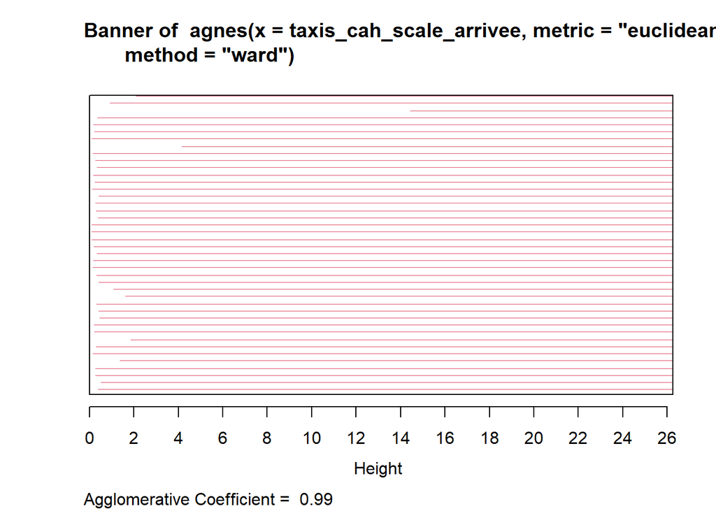

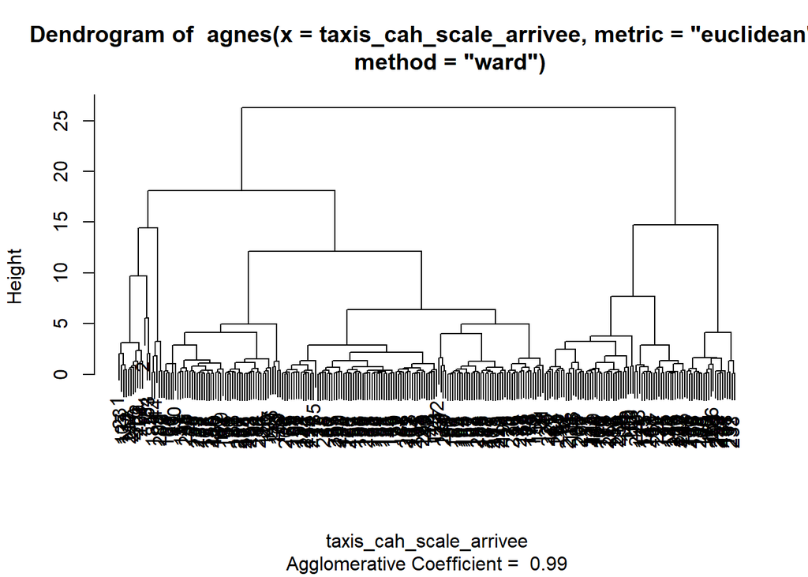

```r
plot(taxis_cah_fait_arrivee)
```

### Affichage du graphique des gains d’inertie inter-classe

```r
sortedHeight_arrivee<- sort(taxis_cah_fait_arrivee$height, decreasing= TRUE)
```

```r
relHeight_arrivee<-sortedHeight_arrivee/ sum(sortedHeight_arrivee)*100
```

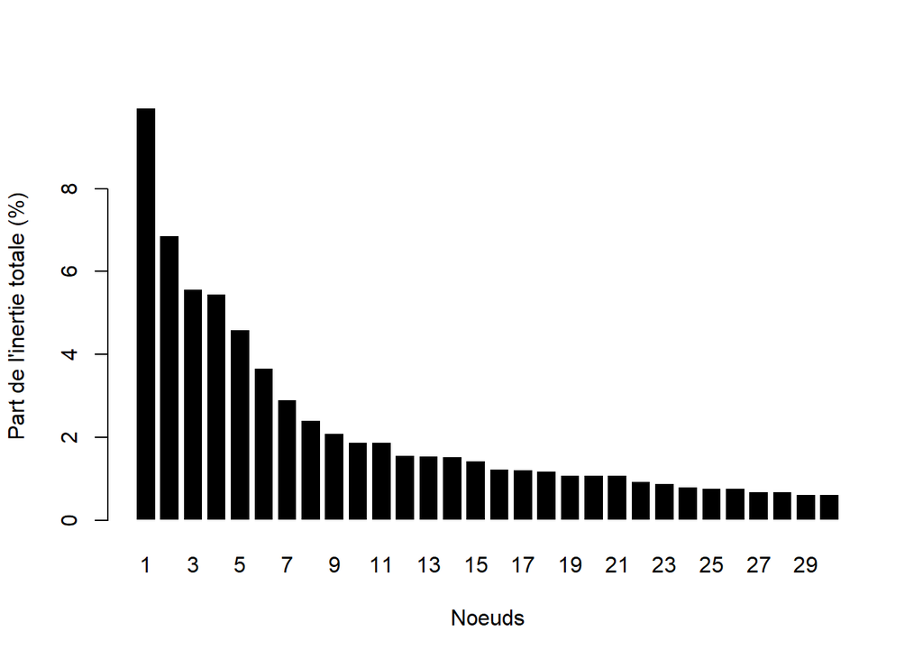

```r
barplot(relHeight_arrivee[1:30], names.arg=seq(1, 30, 1), col= "black", border= "white", xlab= "Noeuds",ylab= "Part de l'inertie totale (%)")
```

```r
clus_zones_arrivee <- cutree(taxis_cah_fait_arrivee, k = 3)
```

```r
zones_cluster_arrivee <- as.data.frame(taxis_cah_arrivee)
```

```r
zones_cluster_arrivee$clus <- factor(clus_zones_arrivee,
                            levels = 1:3,
                            labels = paste("Classe", 1:3))
```

```r
zones_cluster_arrivee <- zones_cluster_arrivee %>% select (ID_zone_arr = zone_arrivee, nb_trajets, passagers_moyen, distance_moyenne, montant_moyen, clus)
```

### Création du tableau récapitulatif des classes

```r
recap_clus_zones_arrivee <- zones_cluster_arrivee %>% group_by(clus) %>%
  summarise(nb_trajets_moy = mean(nb_trajets),
            passagers_moyen = mean(passagers_moyen),
            distance_moyenne = mean(distance_moyenne),
            montant_moyen = mean(montant_moyen))
```

```r
synthese_cah_taxis_arrivee <- recap_clus_zones_arrivee %>% mutate(
  NB_TRAJETS_MOY = mean(taxis_cah_OK_arrivee$nb_trajets),
  PASSAGERSMOY = mean(taxis_cah_OK_arrivee$passagers_moyen),
  DISTANCEMOY = mean(taxis_cah_OK_arrivee$distance_moyenne),
  MONTANTMOY = mean(taxis_cah_OK_arrivee$montant_moyen),
  nb_trajets = (nb_trajets_moy - NB_TRAJETS_MOY)/NB_TRAJETS_MOY*100,
  passagers = (passagers_moyen - PASSAGERSMOY)/PASSAGERSMOY*100,
  distance = (distance_moyenne - DISTANCEMOY)/DISTANCEMOY*100,
  montant = (montant_moyen - MONTANTMOY)/MONTANTMOY*100)
```

```r
synthese_cah_taxis_OK_arrivee <- data.frame(synthese_cah_taxis_arrivee[, c("clus", "nb_trajets", "passagers", "distance", "montant")])
```

```r
gather_arrivee <- synthese_cah_taxis_OK_arrivee %>% gather(key=variable, value= "value", nb_trajets:montant)
```

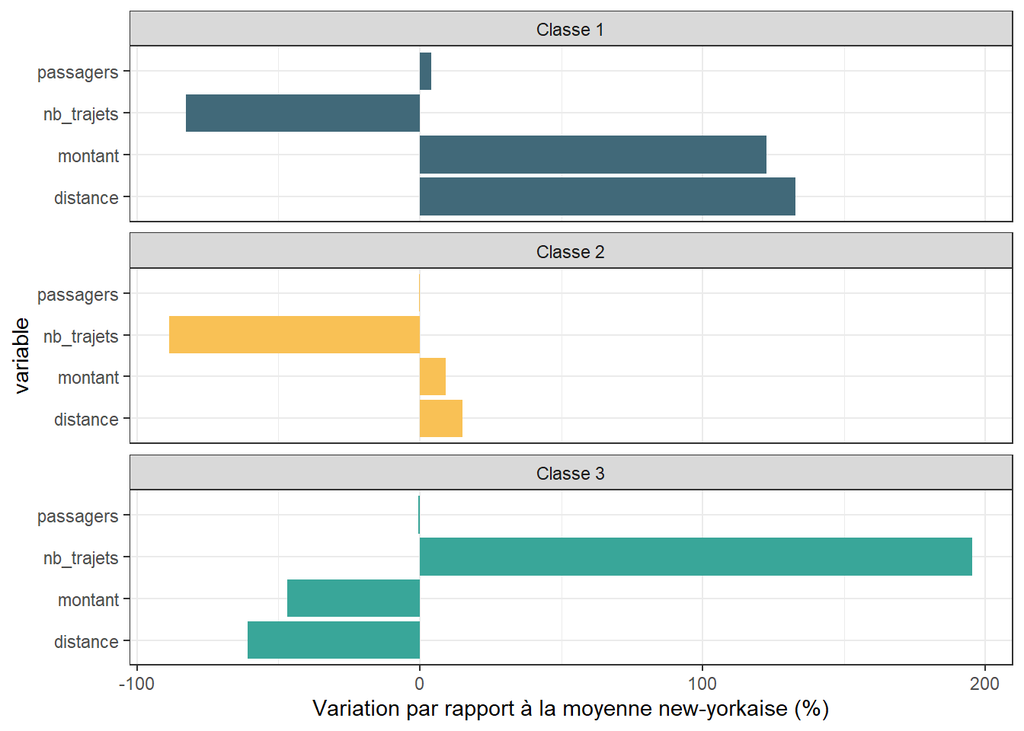

```r
ggplot(gather_arrivee, aes(x=variable, y=value, fill=clus)) +
  geom_bar(stat = "identity") +
  coord_flip() +
  scale_fill_manual(values=c("#416979","#f9c155","#39a699","#FF4136","#FF851B", "#1f78b4")) +
  ylab("Variation par rapport à la moyenne new-yorkaise (%)") +
  theme_bw() +
  theme(legend.position = "none") +
  facet_wrap(~clus, ncol = 1)
```

### Jointure du résultat de la typologie dans la couche des zones d’arrivée

```r
zones_trajets_cah_arrivee <- merge(taxis_zones_arrivee, zones_cluster_arrivee, by = "ID_zone_arr")
```

### Création de la carte

```r
par(mar=c(0,0,1.2,0))
```

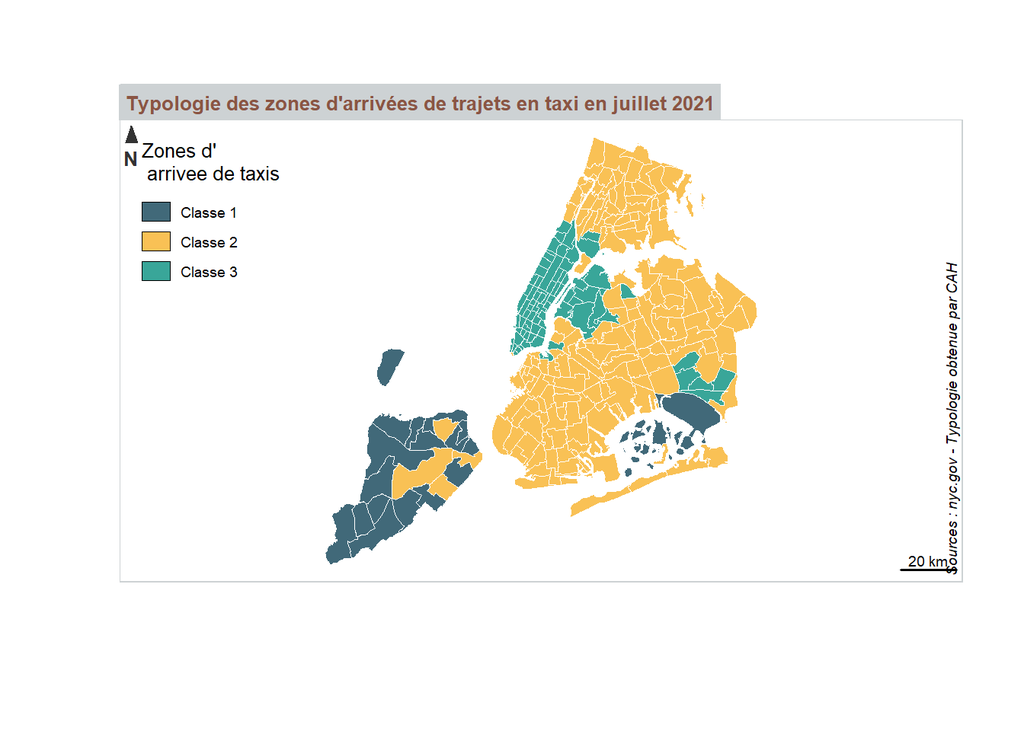

```r
typoLayer(
  x = zones_trajets_cah_arrivee,
  var="clus",
  col = c("#416979","#f9c155","#39a699","#FF4136","#FF851B", "#1f78b4"),
  lwd = 0.1,
  border = "white",
  legend.values.order = c("Classe 1",
                        "Classe 2",
                        "Classe 3"),
  legend.pos = "topleft",
  legend.title.txt = "Zones d' \n arrivee de taxis",
  legend.nodata = "Aucun départ")

layoutLayer(title = "Typologie des zones d'arrivées de trajets en taxi en juillet 2021",
            author = "Sources : nyc.gov - Typologie obtenue par CAH",
            scale = 20, frame = TRUE, col = "#cdd2d4", coltitle = "#8A5543",
            north(pos = "topleft"), tabtitle=TRUE, horiz = FALSE)
```